# Spam Detection

Kami Uckardes

12/19/2020

### Importing Necessary Packages and Dataset

In this study dplyr and tidyverse packages are used for data manipulation, rpart,rpartplot and rattle packages are used to construct and visualize CART models.

```r
library(tidyverse)
library(dplyr)
library(rpart)
library(rpart.plot)
library(rattle)

spamdata <- read.csv(file = 'spambase.csv')
```

### Pre-processing and Making Some Adjustments on Dataset

- In order to get reliable results and creating reliable model, only complete cases are kept in dataset. After this process, 25% of data is classified as test data and remaining part is classifed as training data.
- In dataset, under class variable, 1 was representing spam and 0 was represting not spam. To make this part clear, 1 is changed with Spam and 0 is changed with Not Spam, and this new classes are kept in new factor variable, named spclass. And class variable is removed from dataset.

```r
set.seed(58)

  spamdata = spamdata%>%
  filter(complete.cases(.)) %>%
  mutate(train_test = ifelse(runif(nrow(.)) < 0.25,"test","train"))%>%
  mutate(spclass = ifelse(spamdata$class == 1 ,'Spam','Not Spam'))%>%
  tbl_df() %>% select(-class)

spamdata$spclass <- factor(spamdata$spclass)
```

## Classification and Regression Trees (CART)

A regression tree is created with rpart and visualized with rpart.plot. Regression tress are type of decision trees.

Looking the tree below, we can say that;

- 60% of the data is not spam and 40% is spam. (With looking the node located in top)
- If the char_freq_24% is not less than %5.6, and word_freq_hp is greater than eqaul to 41%, the probability of the mail being spam is only 6 percent.

These are just some of the interpretations, it is possible to make some others.

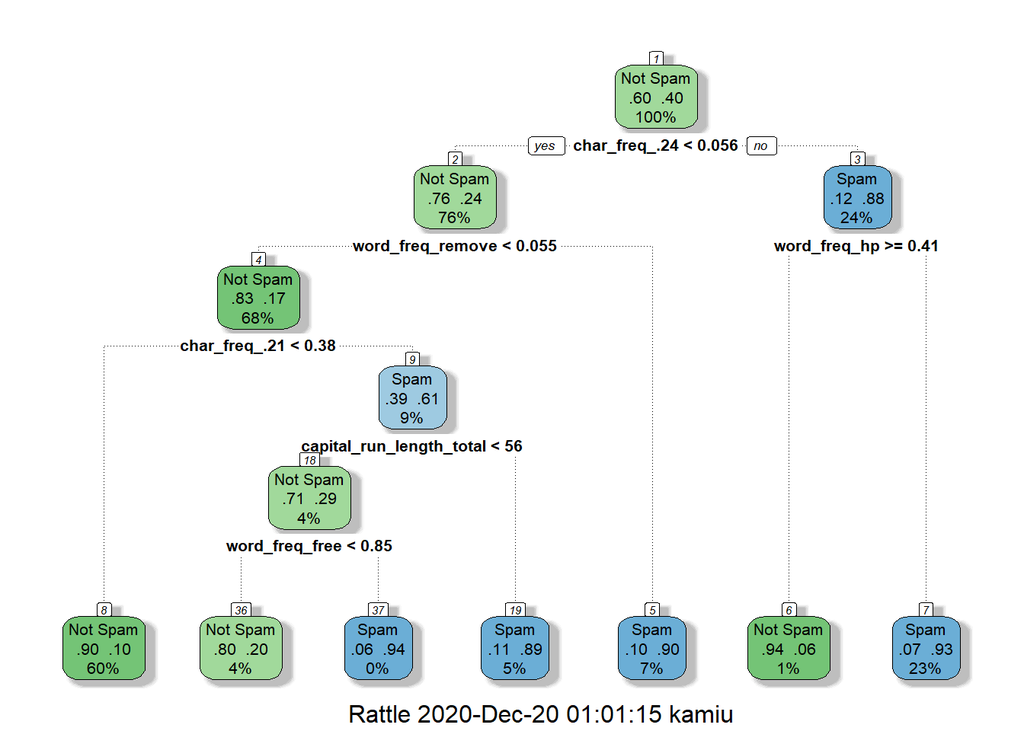

```r
spam_train <- spamdata %>% filter(train_test == "train") %>% select(-train_test)
fit <- rpart(spclass ~ ., method="class", data=spam_train)
fancyRpartPlot(fit)
```

### In Sample Prediction

- In sample prediction means, creating/fitting a model with our training set and testing it again with it.
- We see some prediction results of our model, and the accuracy of it the tables below, respectively.

```r
spam_in_sample <- predict(fit)
print(head(spam_in_sample))
```

```
##     Not Spam      Spam
## 1 0.11377246 0.8862275
## 2 0.06565657 0.9343434
## 3 0.09917355 0.9008264
## 4 0.09917355 0.9008264
## 5 0.89661930 0.1033807
## 6 0.89661930 0.1033807
```

```r
in_sample_prediction =
  cbind(
    spam_in_sample %>% tbl_df %>%
      transmute(spam_predict = ifelse(Spam >= 0.5,1,0)),
    spam_train %>%
      transmute(spam_actual = ifelse(spclass == 'Spam',1,0))
  ) %>% tbl_df %>%
  mutate(correct_class = (spam_predict == spam_actual)) %>%
  group_by(correct_class) %>%
  summarise(count=n(),percentage=n()/nrow(.))

print(in_sample_prediction)
```

```
## # A tibble: 2 x 3
##   correct_class count percentage
##   <lgl>         <int>      <dbl>
## 1 FALSE           335     0.0977
## 2 TRUE           3094     0.902
```

### Out of Sample Prediction

- Out of the sample prediction means, creating/fitting a model with our training set and testing it with our test set.
- We see some prediction results of our model, and the accuracy of it the tables below, respectively.

```r
spam_test <- spamdata %>% filter(train_test=="test") %>% select(-train_test)
spam_predict <- predict(fit,newdata=spam_test)
print(head(spam_predict))
```

```
##     Not Spam      Spam
## 1 0.06565657 0.9343434
## 2 0.89661930 0.1033807
## 3 0.09917355 0.9008264
## 4 0.06565657 0.9343434
## 5 0.06565657 0.9343434
## 6 0.11377246 0.8862275
```

```r
out_of_sample_prediction =
  cbind(
    spam_predict %>% tbl_df %>%
      transmute(spam_predict = ifelse(Spam >= 0.5,1,0)),
    spam_test %>% tbl_df %>%
      transmute(spam_actual = ifelse(spclass == "Spam",1,0))
  ) %>%
  mutate(correct_class = (spam_predict == spam_actual)) %>%
  group_by(correct_class) %>%
  summarise(count=n(),percentage=n()/nrow(.))

print(out_of_sample_prediction)
```

```
## # A tibble: 2 x 3
##   correct_class count percentage
##   <lgl>         <int>      <dbl>
## 1 FALSE           113     0.0964
## 2 TRUE           1059     0.904
```

- In short, our model accuracy is **90.2%** and **90.4%** in *‘In sample prediction’* and *‘Out of the sample prediciton’*, respectively.

## Logistic Regression

- Logistic regression predicts whether something is (binary) True or False, or *Spam* and *Not Spam* in our case.
- Some notes about **Logit** and **Probit**;
  - In most scenarios, the logit and probit models fit the data equally well, with the following two exceptions.
  - *Logit* is definitely better in the case of “extreme independent variables”.
  - *Probit* is better in the case of “random effects models”.

[For further details about Logit and Probit](https://stats.stackexchange.com/questions/20523/difference-between-logit-and-probit-models)

```r
spam_logit_model <- glm(spclass ~ ., data=spam_train,family=binomial(link = "logit"))
spam_probit_model <- glm(spclass ~ ., data=spam_train,family=binomial(link = "probit"))
```

### Logit - In Sample

```r
spam_logit_in_sample <- predict(spam_logit_model,type="response")

spam_logit_in_sample_prediction <-
  data.frame(in_sample=(spam_logit_in_sample >= 0.5)*1,
             actual=(spam_train$spclass == "Spam")*1) %>%
  mutate(correct_class= (in_sample == actual)) %>%
  group_by(correct_class) %>%
  summarise(count=n(),percentage=n()/nrow(.))

print(spam_logit_in_sample_prediction)
```

```
## # A tibble: 2 x 3
##   correct_class count percentage
##   <lgl>         <int>      <dbl>
## 1 FALSE           249     0.0726
## 2 TRUE           3180     0.927
```

### Logit - Out of Sample

```r
spam_logit_out_of_sample <- predict(spam_logit_model,newdata=spam_test,type="response")

spam_logit_out_of_sample_prediction <-
  data.frame(out_of_sample=(spam_logit_out_of_sample >= 0.5)*1,
             actual=(spam_test$spclass == "Spam")*1) %>%
  mutate(correct_class= (out_of_sample == actual)) %>%
  group_by(correct_class) %>%
  summarise(count=n(),percentage=n()/nrow(.))

print(spam_logit_out_of_sample_prediction)
```

```
## # A tibble: 2 x 3
##   correct_class count percentage
##   <lgl>         <int>      <dbl>
## 1 FALSE            81     0.0691
## 2 TRUE           1091     0.931
```

### Probit - In Sample

```r
spam_probit_in_sample <- predict(spam_probit_model,type="response")

spam_probit_in_sample_prediction <-
  data.frame(in_sample=(spam_probit_in_sample >= 0.5)*1,
             actual=(spam_train$spclass == "Spam")*1) %>%
  mutate(correct_class= (in_sample == actual)) %>%
  group_by(correct_class) %>%
  summarise(count=n(),percentage=n()/nrow(.))
print(spam_probit_in_sample_prediction)
```

```
## # A tibble: 2 x 3
##   correct_class count percentage
##   <lgl>         <int>      <dbl>
## 1 FALSE           400      0.117
## 2 TRUE           3029      0.883
```

### Probit - Out of Sample

```r
spam_probit_out_of_sample <- predict(spam_probit_model,newdata=spam_test,type="response")

spam_probit_out_of_sample_prediction <-
  data.frame(out_of_sample=(spam_probit_out_of_sample >= 0.5)*1,
             actual=(spam_test$spclass == "Spam")*1) %>%
  mutate(correct_class= (out_of_sample == actual)) %>%
  group_by(correct_class) %>%
  summarise(count=n(),percentage=n()/nrow(.))

print(spam_probit_out_of_sample_prediction)
```

```
## # A tibble: 2 x 3
##   correct_class count percentage
##   <lgl>         <int>      <dbl>
## 1 FALSE           128      0.109
## 2 TRUE           1044      0.891
```

## Benchmark

- With looking the accuracy ratios below, we can conclude that;
  - **Logistic regression with Logit Link** is the best model with the accuracy of **92.74%** and **93.09%**, in *‘In sample prediction’* and *‘Out of the sample prediciton’*, respectively.

```r
complete_benchmark <- data.frame(
  model = c("CART","Logistic Reg. - Logit Link","Logistic Reg. - Probit Link"),
  in_sample_accuracy = c(
    in_sample_prediction %>% filter(correct_class) %>% transmute(round(percentage,4)) %>% unlist(),
    spam_logit_in_sample_prediction %>% filter(correct_class) %>% transmute(round(percentage,4)) %>% unlist(),
    spam_probit_in_sample_prediction %>% filter(correct_class) %>% transmute(round(percentage,4)) %>% unlist()
  ),
  out_of_sample_accuracy = c(
    out_of_sample_prediction %>% filter(correct_class) %>% transmute(round(percentage,4)) %>% unlist(),
    spam_logit_out_of_sample_prediction %>% filter(correct_class) %>% transmute(round(percentage,4)) %>% unlist(),
    spam_probit_out_of_sample_prediction %>% filter(correct_class) %>% transmute(round(percentage,4)) %>% unlist()
  )
)
print(complete_benchmark)
```

```
##                         model in_sample_accuracy out_of_sample_accuracy
## 1                        CART             0.9023                 0.9036
## 2  Logistic Reg. - Logit Link             0.9274                 0.9309
## 3 Logistic Reg. - Probit Link             0.8833                 0.8908
```

## References

- [Data Source - Spambase](https://datahub.io/machine-learning/spambase)
- [Statistical Models in R: Part 2](https://mef-bda503.github.io/archive/fall17/files/intro_to_ml_2.html)

You may click [here](https://pjournal.github.io/mef04-KamiUckardes/) to reach other items of my progress journal.